# YellowDig Code Through: Datapasta

Shriver Smith

26 February, 2021

## Introduction

This Code Through will introduce you to a package called ‘datapasta’. This package will allow you to take data from a website and copy/paste it into R as a tibble or dataframe instead of building a dataset from scratch and saving you time. This package will also create tibbles and can be used to copy data from Excel files as well as Jupyter files.

## Content Overview

I will be using data from the Las Vegas Review-Journal on the Las Vegas Raiders football statistics. The website publishes various statistics throughout the year on the Las Vegas Raiders. This demonstration will focus on the copy/paste function of this package from a live website.

## Steps

Package needed: datapasta

```r
#Load package datapasta

library(datapasta)
```

Data to work with, which was taken from the Las Vegas Review-Journal, which now covers the Las Vegas Raiders NFL football team after making Las Vegas, NV their new home. I have chosed to use the rushing stats for this code through.

[Las Vegas Review-Journal: Las Vegas Raiders Rushing Stats](https://www.reviewjournal.com/vegas-nation-team/#tab-stats)

[figure not shown]

Now that we have the data in view, we can just copy by right clicking our mouse. And you can see the selected data in blue.

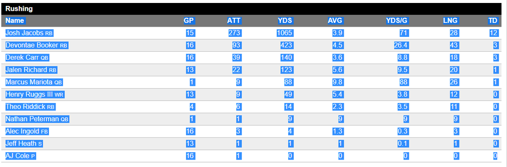

Insert a new R code block and then select ‘paste as data.frame’ from the Addins menu a the top of RStudio.  
Just 3 easy steps, that’s it!

[figure not shown]

After following the previous steps, you data should come out like this! The output is identical to that found on the Las Vegas Review-Journal. **NOTE:** I added the dataframe name rushingStats, you’ll have to name your own dataframe.

```r
rushingStats<-data.frame(
  stringsAsFactors = FALSE,
       check.names = FALSE,
              Name = c("Josh Jacobs RB",
                       "Devontae Booker RB","Derek Carr QB","Jalen Richard RB",
                       "Marcus Mariota QB","Henry Ruggs III WR","Theo Riddick RB",
                       "Nathan Peterman QB","Alec Ingold FB","Jeff Heath S",
                       "AJ Cole P"),
                GP = c(15L, 16L, 16L, 13L, 1L, 13L, 4L, 1L, 16L, 13L, 16L),
               ATT = c(273L, 93L, 39L, 22L, 9L, 9L, 6L, 1L, 3L, 1L, 1L),
               YDS = c(1065L, 423L, 140L, 123L, 88L, 49L, 14L, 9L, 4L, 1L, 0L),
               AVG = c(3.9, 4.5, 3.6, 5.6, 9.8, 5.4, 2.3, 9, 1.3, 1, 0),
           `YDS/G` = c(71, 26.4, 8.8, 9.5, 88, 3.8, 3.5, 9, 0.3, 0.1, 0),
               LNG = c(28L, 43L, 18L, 20L, 26L, 12L, 11L, 9L, 3L, 1L, 0L),
                TD = c(12L, 3L, 3L, 1L, 1L, 0L, 0L, 0L, 0L, 0L, 0L)
)
rushingStats
```

| Name | GP | ATT | YDS | AVG | YDS/G | LNG | TD |
| --- | --- | --- | --- | --- | --- | --- | --- |
| Josh Jacobs RB | 15 | 273 | 1065 | 3.9 | 71.0 | 28 | 12 |
| Devontae Booker RB | 16 | 93 | 423 | 4.5 | 26.4 | 43 | 3 |
| Derek Carr QB | 16 | 39 | 140 | 3.6 | 8.8 | 18 | 3 |
| Jalen Richard RB | 13 | 22 | 123 | 5.6 | 9.5 | 20 | 1 |
| Marcus Mariota QB | 1 | 9 | 88 | 9.8 | 88.0 | 26 | 1 |
| Henry Ruggs III WR | 13 | 9 | 49 | 5.4 | 3.8 | 12 | 0 |
| Theo Riddick RB | 4 | 6 | 14 | 2.3 | 3.5 | 11 | 0 |
| Nathan Peterman QB | 1 | 1 | 9 | 9.0 | 9.0 | 9 | 0 |
| Alec Ingold FB | 16 | 3 | 4 | 1.3 | 0.3 | 3 | 0 |
| Jeff Heath S | 13 | 1 | 1 | 1.0 | 0.1 | 1 | 0 |

[output cut: 1 more lines]

## Further Resources

Other websites that are helpful in learning more about Datapasta:

- [RDocumentation Datapasta](https://www.rdocumentation.org/packages/datapasta/versions/1.0.0)
- [Datapasta 3.1.1 ’Leave to Simmer](https://milesmcbain.github.io/datapasta/)
- [Cran Datapasta Spec](https://cran.rstudio.com/web/packages/datapasta/datapasta.pdf)

## Works Cited

- Chan. (2018, August 21).Paste data into R effortlessly with DataPasta.[Video].YouTube.https://www.youtube.com/watch?v=-a7wb47aOMw
- McBain, Miles. (2020, December 30).*Datapasta*(Version 3.1.1).Github.https://github.com/MilesMcBain/datapasta
- Las Vegas Review-Journal.(2021).Las Vegas Raiders Rushing Stats 2020.https://www.reviewjournal.com/vegas-nation-team/#tab-stats